# FigureYa259circLink

**Author(s)**: Zongcheng Li  
**Reviewer(s)**: Ying Ge, Yasi Zhang  
**Date**: 2025-12-03

## 1 Academic Citation

If you use this code in your work or research, we kindly request that you cite our publication:

Xiaofan Lu, et al. (2025). FigureYa: A Standardized Visualization Framework for Enhancing Biomedical Data Interpretation and Research Efficiency. iMetaMed. https://doi.org/10.1002/imm3.70005

## 2 需求描述 Requirement description

画出这种连线图。

Draw this connection diagram.

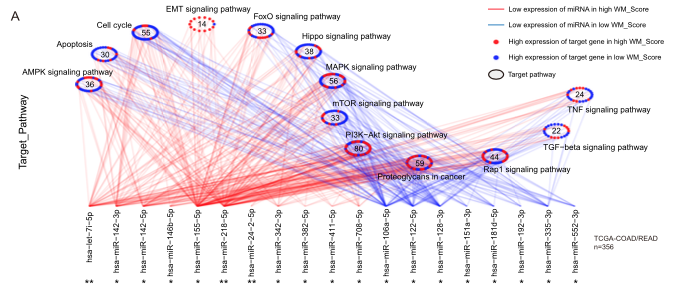

From https://molecular-cancer.biomedcentral.com/articles/10.1186/s12943-021-01322-w, from the same article as FigureYa260CNV.

类似的图：

A similar image:

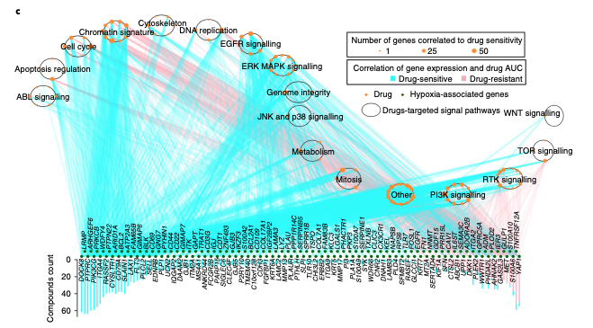

出自：https://doi.org/10.1038/s42255-019-0045-8，跟FigureYa174squareCross、FigureYa199crosslink、FigureYa256panelLink出自同一篇文章。这篇文章以连线著称，总是被模仿，不知道会不会被超越。

From https://doi.org/10.1038/s42255-019-0045-8, from the same article as FigureYa174squareCross, FigureYa199crosslink, and FigureYa256panelLink. This paper is renowned for its connection designs—constantly imitated, yet to be surpassed.

Fig. 3 | overview of the propensity score algorithm and the hypoxia-associated molecular patterns across cancer types. c, Association between mRNA expression levels of hypoxia-associated genes and drug sensitivity across 1,074 cancer cell lines by Spearman’s rank correlation. The dark green dots along the x axis indicate hypoxia-related genes; the orange dots denote drugs that are clustered by different signalling pathways. The size of the orange dot indicates the number of genes correlated with drug sensitivity (|rs| > 0.3, FDR < 0.05); the bar plot shows the number of drugs correlated with the genes. The pink and cyan lines indicate positive and negative correlation, respectively. JNK, Jun N-terminal kinase.

## 3 应用场景 Application scenarios

展示miRNA-靶基因（或基因-药物等）的关系，连线和节点的颜色代表节点类型（例如例文的high和low WM_Score）。同一通路的基因画在同一圆圈里，并标注通路名。

为了画这个图，完善了crosslink包，该R包会继续添加更多有趣的连线功能，感兴趣可前往https://github.com/zzwch/crosslink查看最新版本及功能，在github上还能提交issue跟作者直接交流。

This figure displays miRNA-target gene (or gene-drug, etc.) relationships, where the colors of connecting lines and nodes represent node types (e.g., high vs. low WM_Score as shown in the example). Genes from the same pathway are grouped within circular clusters labeled with pathway names.

To create this visualization, we enhanced the crosslink R package, which will continue to incorporate more innovative connection features. Those interested can visit https://github.com/zzwch/crosslink to explore the latest version and functionalities. GitHub also allows users to submit issues for direct communication with the author.

## 4 环境设置 Environment Setup

```r
source("install_dependencies.R")
```

```
## Starting R package installation...
## ===========================================
##
## Installing CRAN packages...
## Package already installed: ggplot2
## Package already installed: magrittr
## Package already installed: tidyverse
## Package already installed: rlang
## Package already installed: patchwork
##
## ===========================================
## Package installation completed!
## You can now run your R scripts in this directory.
```

```r
source("crosslink.R") # From R package crosslink
source("layout.R") # From R package crosslink
source("transfromation.R") # From R package crosslink
source("utils.R") # From R package crosslink

library(magrittr)    # 管道操作符 Pipe operations
library(tidyverse)   # 数据整理与可视化 Data wrangling & visualization
```

```r
library(ggplot2)     # 绘图 Plotting
library(rlang)       # 编程辅助 Programming tools
library(patchwork)   # 拼图 Plot composition

# 显示英文报错信息
# Show English error messages
Sys.setenv(LANGUAGE = "en")

# 禁止chr转成factor
# Prevent character-to-factor conversion
options(stringsAsFactors = FALSE)
```

## 5 输入文件 Input Files

easy_input_links.csv，连线表示source（miRNA）和target（靶基因）的关系。连线的颜色表示source的类型source_type（high WM_Score和low WM_Score）。

easy_input_nodes.csv，key（包括source和target）所在的path（通路）信息。

- 节点的颜色表示target的类型type（high WM_Score和low WM_Score）。
- source（miRNA）的path列写为source，source的type列是source的type，因此跟easy_input_links.csv的source_type列一致，signif列的内容会标在图中source的名字下面。
- 如果想要例文2那样的效果，用target节点的大小表示number of genes correlated to drug sensitivity，就加一列size，用于控制targe节点的大小，记得把文档中`# size = size`前面的`#`删掉。

easy_input_links.csv represents the relationship between the source (miRNA) and the target (target gene), where the color of the line indicates the type of the source (source_type: high WM_Score and low WM_Score).

easy_input_nodes.csv contains the pathway information (path) for the keys (including both source and target).

- The color of the nodes represents the type of the target (type: high WM_Score and low WM_Score).
- For the source (miRNA), the path column should be labeled as “source,” and the type column corresponds to the source’s type, which should match the source_type column in easy_input_links.csv. The content of the signif column will be displayed below the name of the source in the diagram.
- If you want an effect similar to Example 2, where the size of the target nodes represents the “number of genes correlated to drug sensitivity,” add a column named “size” to control the size of the target nodes. Remember to remove `#` in `# size = size` in the document.

```r
links <- read.csv("easy_input_links.csv")
nodes <- read.csv("easy_input_nodes.csv")

# 获取所有通路的名字
# Get all pathway names
paths <- unique(nodes[nodes$path != "source", ]$path)

# 把"source"排在前面
# Place "source" first
nodes$path <- factor(nodes$path, levels = c("source", paths))

# 连线的颜色
# Line colors
src_up_col <- "red"
src_dn_col <- "blue"

# target节点的颜色
# Target node colors
tar_up_col <- "red"
tar_dn_col <- "blue"
```

## 6 开始画图 Plotting

### 6.1 快速预览 Take a glance of the data

> 重要提示！节点和边数据中不能包含列名 ‘node’、‘cross’、‘node.type’、‘x’、‘y’、‘degree’！

> IMPORTANT! The colnames of ‘node’, ‘cross’, ‘node.type’, ‘x’, ‘y’, ‘degree’ MUST NOT BE included in nodes and edges!

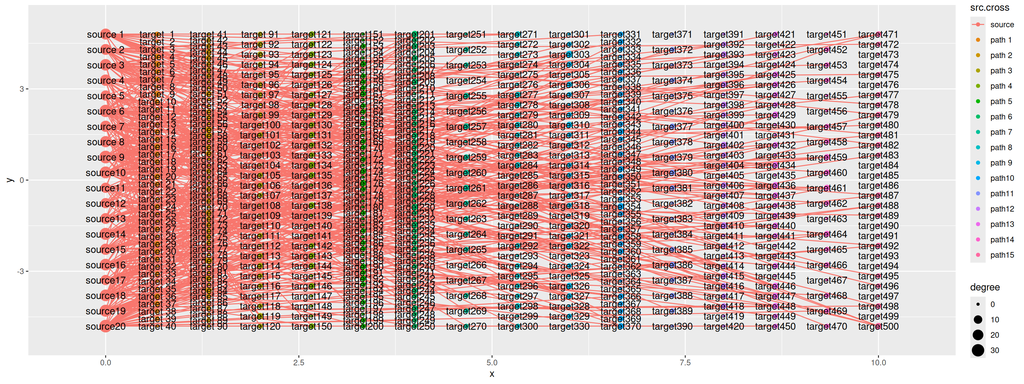

```r
# 使用crosslink函数创建网络布局对象
# Create network layout object using crosslink function
toy <- crosslink(
  nodes = nodes,
  edges = links,
  cross.by = "path",
  xrange = c(0, 10),
  yrange = c(-5, 5),
  spaces = "partition")

# 绘制网络布局图
# Plot the network layout
cl_plot(toy)
```

### 6.2 按通路将靶点转换为圆形分布 Transform the targets into circle by pathways

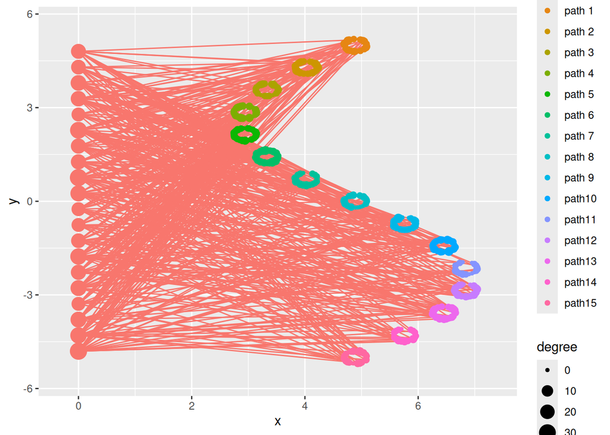

```r
# 自定义函数
# Custom function
toCircle <- function(x, y, rx = 1, ry =1, intensity = 2){
  mapTo2pi <- function(x) {scales::rescale(c(0, x), to = c(0, 2*pi))[-1]}
  data.frame(x, y) %>%
    mutate(group = paste0("group", x)) %>%
    mutate(yy = scales::rescale(-x, to = range(y))) %>%
    mutate(xx = mean(x) + intensity * sin(yy %>% mapTo2pi),) %>%
    group_by(group) %>%
    mutate(tri = rank(y, ties.method = "first") %>% mapTo2pi)  %>%
    ungroup() %$%
    data.frame(
      x = xx + rx*sin(tri),
      y = yy + ry*cos(tri))
}

# 应用圆形变换函数到网络布局对象
# Apply circular transformation to network layout object
toy_circle <- toy %>% tf_fun(
  crosses = paths,
  along = "xy",
  fun = toCircle,
  rx = 0.2, ry = 0.2)

# 绘制变换后的网络图（不显示标签）
# Plot transformed network (without labels)
toy_circle %>% cl_plot(label = NA)
```

### 6.3 后处理 Post-processing

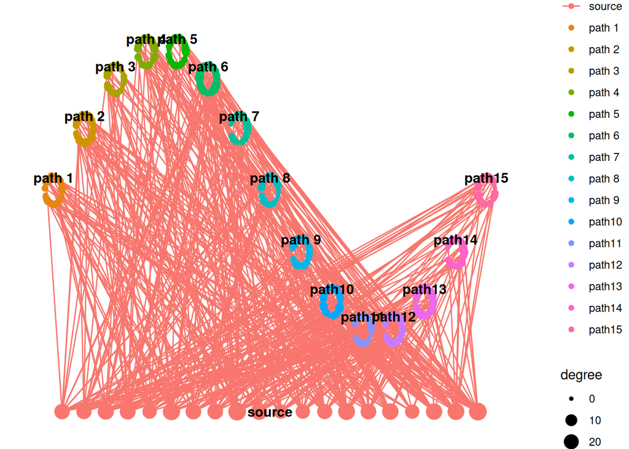

```r
## 对圆形布局进行几何变换
## Geometric transformations for circular layout
toy_final <- toy_circle %>%
  tf_rotate(angle = -90) %>%
  tf_flip(axis = "x", crosses = paths) %>%
  tf_shift(y = 8, crosses = paths, relative = F) %>%
  set_header()

## 可视化后处理结果
## Visualize post-processing results
toy_final %>% cl_plot(label = NA) %>% cl_void()
```

### 6.4 微调 Fine tuning

```r
# 显示可用图形属性
# Display available graphic attributes
show_aes(toy_final)
```

```
## Available meta.data names are showing below.
## Cross: node, node.type, x, y, cross, key, type, path, signif, degree
## Link: src, tar, source_type, src.cross, tar.cross, source, target, src.degree, tar.degree, x, y, xend, yend
## Header: node, node.type, x, y, cross, header
```

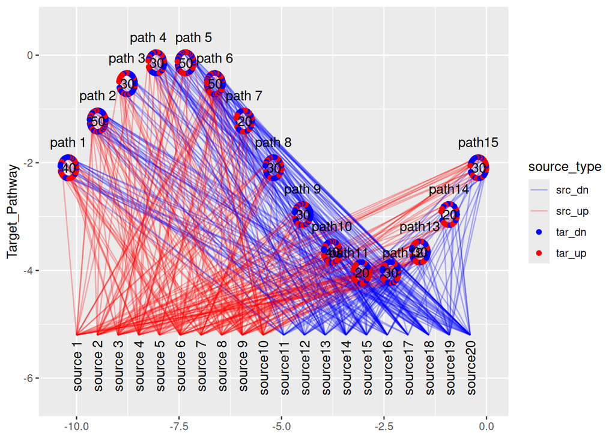

```r
ggplot() +
  # 每个模块相对独立，可根据需要调整不同图层的叠加顺序
  # Each module is relatively independent, you can adjust the layer stacking order as needed

  # 路径的黑色圆圈（绘制在最底层，部分会被靶点覆盖）
  # Black circles for pathways (drawn at the bottom layer, partially covered by target points)
  ggforce::geom_circle(
    mapping = aes(x0 = x0, y0 = y0, r = r),
    data = get_cross(toy_final) %>% filter(cross != "source") %>%
      group_by(path) %>%
      transmute(
        x0 = mean(x),
        y0 = mean(y),
        r = 0.2
      ) %>% unique(),
    show.legend = F
  ) +

  # 连线（miRNA-靶基因关系）
  # Connection lines (miRNA-target relationships)
  geom_segment(
    mapping = aes(x, y, xend = xend, yend = yend, color = source_type),
    data = get_link(toy_final),
    alpha = 0.3
  ) +

  # 靶点节点
  # Target nodes
  geom_point(
    mapping = aes(x, y,
                  # size = size,
                  color = type),
    data = get_cross(toy_final) %>% filter(cross != "source")
  ) +

  # 添加文字：靶点所属通路名称
  # Add text: Pathway names for targets
  ggrepel::geom_text_repel(
    mapping = aes(x, y, label = header), nudge_y = 0.3,
    data = get_header(toy_final) %>% filter(cross != "source"),
    segment.color = NA
  ) +

  # 添加文字：miRNA源节点名称
  # Add text: miRNA source node names
  geom_text(
    mapping = aes(x, y, label = key), angle = 90, hjust = 1, nudge_y = -0.1,
    data = get_cross(toy_final) %>% filter(cross == "source")
  ) +

  # 添加文字：每个通路的靶点数量
  # Add text: Number of targets per pathway
  geom_text(
    mapping = aes(x, y, label = num),
    data = get_cross(toy_final) %>% filter(cross != "source") %>%
      group_by(path) %>%
      transmute(
        x = mean(x),
        y = mean(y),
        num = n()
      ) %>% unique()
  ) +

  # 颜色配置
  # Color settings
  scale_color_manual(values = c(
      src_up = src_up_col, src_dn = src_dn_col,
      tar_up = tar_up_col, tar_dn = tar_dn_col)) +
  labs(x = NULL, y = "Target_Pathway") +
  scale_y_continuous(expand = expansion(mult = c(0.25,0.1))) -> p

p
```

> 如果想要像例文2那样给source也画上点，就运行下面这段

> If you want to plot points for the source nodes as in Example 2, run the following code

```r
# 画source节点
# Plot source nodes
p <- p + geom_point(
  mapping = aes(x, y),
  data = get_cross(toy_final) %>% filter(cross == "source")
  )
```

### 6.5 添加注释图 Add annotation plots

把source的’signif’标注在source名字的下方

Place the ‘signif’ annotation below the source names

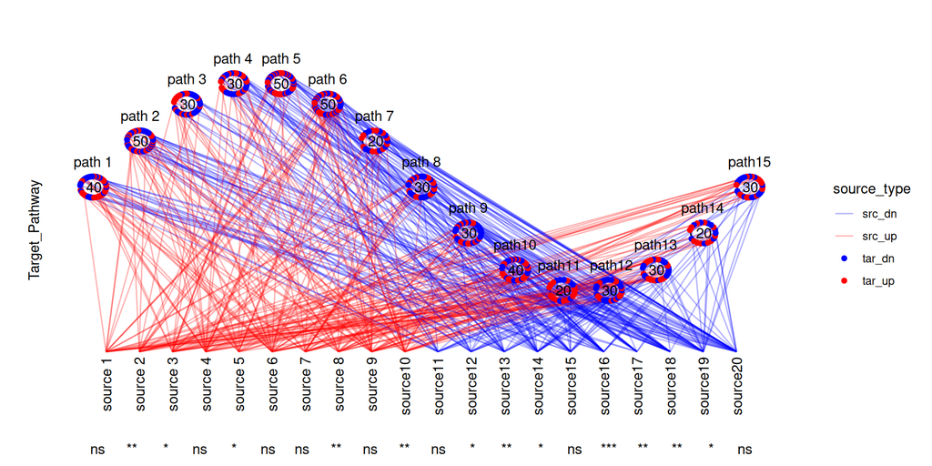

```r
# 创建带注释的circLink图
# Create circLink plot with annotations
cl_plot2(
  p %>% cl_void(th = theme(
    axis.title = element_text())),
  object = toy_final,
  annotation = cl_annotation(
    bottom = ggplot() +
      geom_text(
        mapping = aes(seq_along(key), 0, label = signif),
        data = nodes %>% filter(path == "source")
      ) + theme_void()
    ,
    bottom.by = "source", bottom.height = 0.05
  )
)
```

```r
# 保存图形为PDF文件
# Save plot as PDF file
ggsave("circLink.pdf", width = 10, height = 5)
```

## 7 附：示例数据生成过程 Appendix: Example Data Generation Process

```r
# 生成节点名称
# Generate node names
sources <- paste0("source", 1:20 %>% format)
targets <- paste0("target", 1:500 %>% format)
paths <- paste0("path", 1:15 %>% format)

# 创建节点数据框
# Create node dataframe
nodes <- data.frame(
  key = c(sources, targets),
  type = c(rep("src_up", length(sources)/2),
           rep("src_dn", length(sources)/2),
           sample(c("tar_up", "tar_dn"), length(targets), replace = T)),
  path = c(rep("source", length(sources)),
           rep(paths, times = c(
             40, 50, 30, 30, 50, 50, 20, 30, 30, 40, 20, 30, 30, 20, 30
           ))) %>% factor(
             levels = c("source", paths)
           ),
  signif = c(sample(c("*", "**", "***", "ns"), length(sources), replace = T),
             rep(NA, length(targets)))
)

# 生成连接关系数据
# Generate link relationships
link_n <- 500
set.seed(666)
links <- data.frame(
  src = sample(sources, link_n, replace = T),
  tar = sample(targets, link_n, replace = T)) %>%
  unique() %>%
  mutate(source_type = nodes$type[match(src, nodes$key)])

# 保存示例数据文件
# Save example data files
write.csv(links, "easy_input_links.csv", row.names = F, quote = F)
write.csv(nodes, "easy_input_nodes.csv", row.names = F, quote = F)
```